# Tuning Spacemap

Chris Conley

March 11, 2016

## Tuning Strategy for Managing Computational Constraints

The three tuning parameters in Spacemap provides a rich framework for discovering conditional dependencies between variables in high dimensional biological assays; however, exploring the tuning space can be very computationally demanding. In this tutorial we provided a strategy for finding the neighborhood of good tuning parameters given computational limits. The strategy finds suitiable neighborhoods of each tuning parameter by:

1. Tuning Space on the full data **(X,Y)** and **Y** alone to find a neighborhood of the first tuning parameter, denoted as `slasso`.
2. Tuning Spacemap with the neigbhorhood of `slasso` from step 1, and exploring a broad range of values for `rlasso`. while holding `rgroup=0`.
3. Tuning Spacemap with local neighborhoods on `slasso` and `rlasso` discovered from steps 1 & 2, while exploring a broad range of values for `rgroup > 0`.

We will illustrate the details of this strategy with an example from a simulation. The known truth of the simulation affords an evaluation addressing whether this strategy leads to reasonably tuned parameter selection.

### Simulation Details

Load network simulation 1 which has topology that mimics a genetic regulatory network. The simulation was generated under a multivariate normal assumption with 171 response variables with 14 predictors (i.e. **Y** = response, **X** = predictors). There are 10 predictors that have no `X->Y` edges, 2 predictors each with 13 and 14 `X->Y` edges. Among the response, there are 2 hub variables with degree 12 and 13, but the degree of the other response variables does not exceed 4. There are two disconnected components in the graph of size 94 and 81. The data has been standardized (mean-centered with unit variance) for all variables.

```r
library(spacemap)
data(sim1)
```

Extract data objects and report dimensions and sample size.

```r
dat <- sim1[c("XY", "X", "Y", "Xindex", "Yindex")]
N <- nrow(dat$X)
P <- ncol(dat$X)
Q <- ncol(dat$Y)
```

Extract the true partial correlation values for `X->Y` and `Y--Y` edges. Each non-zero value corresponds to a true edge.

```r
trueParCor <- sim1$trueParCor
str(trueParCor)
```

```
## List of 2
##  $ xy: num [1:14, 1:171] -1.00e-01 -1.42e-16 0.00 0.00 0.00 ...
##  $ yy: num [1:171, 1:171] 1.00 2.26e-18 2.51e-18 -1.46e-17 -1.65e-17 ...
```

## Tuning Example

Tuning will be much faster if parallel computation is leveraged. Set up a parallel backend, in this case for a multicore machine. This code will use all available cores minus 1.

```r
dopar <- TRUE
if (dopar) {
  suppressPackageStartupMessages(library(doParallel))
  suppressPackageStartupMessages(library(parallel))
  ncores <- detectCores()  - 1
  cl <- makeCluster(ncores)
  registerDoParallel(cl)
}
```

## Find a neighborhood for `slasso`

Tune the `slasso` parameter by fitting the Space model to either the response **Y** or jointly **(X,Y)** over a one-dimensional tuning grid. In the current implementation, the tuning parameter scales with the sample size. To find the right tuning scale, use a result from Meihshausen and Buhlmann (2006) which applies when when all `Y` have been standardized to have unit variance. The value of `alpha` is meant to control the false discovery rate.

```r
lam1start <- function(n, q, alpha) {
  sqrt(n) * qnorm(1 - (alpha/ (2*q^2)))
}
lam0 <- lam1start(n = floor(N - N*.10), q = Q, alpha = 0.1)
lam0
```

```
## [1] 53.95659
```

We want to select a neighborhood using this initial value, where `lam0` serves as an approximate lower bound of the neighborhood. We use it as a lower bound because we prefer to start with parsimonious models. Take the initial neighborhood to be [-10% of `lam0`, 190% of `lam0`] as a starting point.

```r
#neighborhood parameter about lam0.
eps.10 <- 0.1
#initial grid size.
ngrid <- 50
#grid
tsp <- expand.grid(slasso = seq(lam0*(1 - eps.10), lam0*(1 + (1 - eps.10)), length = ngrid))
summary(tsp)
```

```
##      slasso
##  Min.   : 48.56
##  1st Qu.: 62.05
##  Median : 75.54
##  Mean   : 75.54
##  3rd Qu.: 89.03
##  Max.   :102.52
```

Since cross-validation is expensive, we can do an initial fit with all samples on **(X,Y)** to get a sense of the model complexity or the models’ degrees of freedom (number of edges) for the chosen neighborhood.

```r
#convergence tolerance
tol <- 1e-6
#max. numbr of iterations for coordinate descent optimation
cd_iter <- 1e7
#number of iterations for estimating diagonal of concentration matrix.
iter <- 3
#ridge parameter for space (for elastic net if desired)
sridge <- 0
#ridge parameter for refit
refitRidge = 0.0
#fit the model to all samples
dfr <- spacemap::initFit(dat = dat, method = "space",
                         tuneGrid = tsp,
                         sridge = 0, tol = tol, cd_iter = cd_iter, iter = iter,
                         Yindex = dat$Yindex, Xindex = dat$Xindex)
```

While there are a number of metrics recorded from `initFit`, we care primarily about the number of `Y--Y` edges reported as `dfParCor` and `X->Y` reported as `dfGamma`. The total number of edges is reported as `dfTotal`

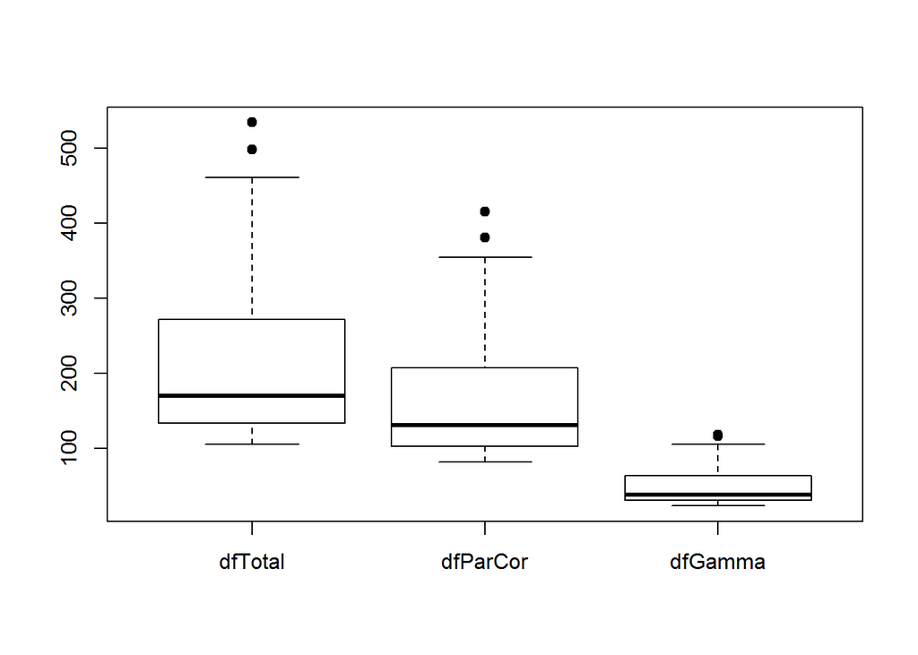

```r
boxplot(dfr[,c("dfTotal", "dfParCor", "dfGamma")], pch = 19)
```

One ought to determine if the degrees of freedom is too high (tuning parameter too low) from factors like how much power from the sample size is afforded, what level FDR is tolerated, and how sparse the network is anticipated to be. Making that determination is not easy, but realistic estimates can dramatically improve computational times. Since we have the true cardinality of the edge set available to us, we can compare the true model comlexity to the complexity of models generated under the initial tuning neighborhood.

```r
#true X->Y edges
nonZeroWhole(sim1$trueParCor$xy, tol)
```

```
## [1] 54
```

```r
#true Y--Y edges
nonZeroUpper(sim1$trueParCor$yy, tol)
```

```
## [1] 156
```

Notice that the initial neighborhood generates fitted model complexities that bounds the true model complexity; this gives confidence that the neighborhood selection procedure is suitable for this example. The more degrees of freedom a model has, the longer it typically takes for model convergence. Selecting a tuning grid that generates models with unreasonably high degrees of freedom will make the cross-validation step take unnecessarily long. This initial fitting procedure helps eliminate unnecessary computation. Since the maximum degrees of freedom under this neighborhood is not extreme, proceed to create cross validation training and test sets.

```r
#for generating cross-validation folds
library(caret)
#sample size
N <- nrow(dat$X)
#number of folds
K <- 10L
set.seed(265616L)
allSets <- seq_len(N)
testSets <- createFolds(allSets, k = K)
trainSets <- lapply(testSets, function(s) setdiff(allSets, s))
```

### Cross-validation with **(X,Y)** input

Now apply cross-validation to Space with **(X,Y)** as input. This should take less than a minute with 4 workers and an intel i7 processor.

```r
tictoc <- system.time({cvSpaceXY <- spacemap::crossValidation(dat = dat, fold = K,
                                                            trainIds = trainSets, testIds = testSets,
                                                            method = "space", tuneGrid = tsp,
                                                            sridge = sridge, tol = tol, iter = iter, cd_iter = cd_iter,
                                                            Xindex = dat$Xindex, Yindex = dat$Yindex,
                                                            refitRidge = refitRidge)})
```

```
## Computing CV scores over the grid...
```

```
## Computing model fit over CV-selected tuning parameters.
```

```r
message("The 10-fold CV took ", round(tictoc[3]/60,2), " minutes")
```

```
## The 10-fold CV took 0.78 minutes
```

The selected tuning parameter of `slasso` is:

```r
cvSpaceXY$tuneGrid
```

```
## [1] 74.98865
```

which is not on the boundary of the grid; this suggests the tuning neighborhood was sufficiently large. Further, we report on the performance of Space with **(X,Y)** input. The performance is broken down into the overall power, FDR, and the Matthew’s correlation coefficient (an average of sensitivity and specificity). The performance specific to `Y--Y` and `X--Y` is also displayed. The CV-vote performance is reported, which corresponds to a model with edges that are selected across the majority of folds.

```r
Perf <- list()
Perf$spaceXY <- spacemap::cvPerf(cvOut = cvSpaceXY,
                               trueParCor = trueParCor,
                               method = "space", tol = tol,
                               Xindex = dat$Xindex, Yindex = dat$Yindex)
library(knitr)
votePerf(Perf$spaceXY)
```

| power | fdr | mcc | powerXY | fdrXY | powerYY | fdrYY |
| --- | --- | --- | --- | --- | --- | --- |
| 0.652381 | 0.041958 | 0.7885613 | 0.6111111 | 0 | 0.6666667 | 0.0545455 |

The power is somewhat limited but the false discovery rate is controlled to reasonable levels with the `vote` procedure producing the lowest FDR with some cost to the power. The `vote` procedure is preferred to the 1-sd rule since it renders comparable power with lower FDR. The `X->Y` power and FDR are smaller than the `Y--Y` power. Inspect the CV-vote-error curve and confirm that the curve is well-behaved. If the CV-error curve is not approximately smooth and multi-collinearity exists between the `X`’s, then applying a ridge penalty in the refit step has been shown to help in an application of gene expression (Y) and copy number (X); a refitted ridge regression is not necessary here. The model was fitted across a broad range of degrees of freedom also.

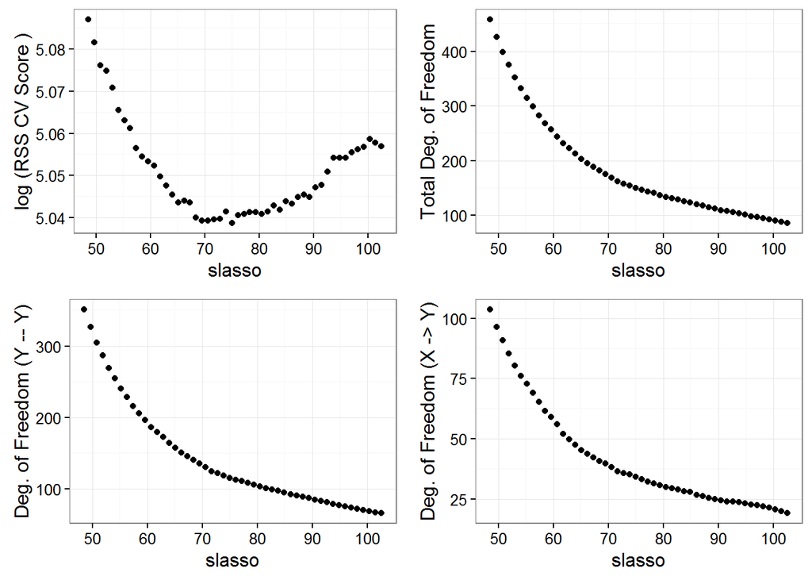

```r
library(ggplot2)
library(reshape2)
library(gridExtra)
cvVis <- spacemap::tuneVis(cvOut = cvSpaceXY, testSetLen = sapply(testSets, length),
                      tuneParam1 = tsp$slasso, tuneParam1Name = "slasso")
grid.arrange(cvVis[[1]], cvVis[[2]],cvVis[[3]],cvVis[[4]])
```

### Cross-validation with **Y** input

Fitting with strictly the **Y** input may be advised if the **X** dimension is very large and slows down the overall computation.

```r
datyy <- dat
datyy$XY <- dat$Y
tictoc <- system.time({cvSpaceYY <- spacemap::crossValidation(dat = datyy, fold = K,
                                                              trainIds = trainSets, testIds = testSets,
                                                              method = "space", tuneGrid = tsp,
                                                              sridge = sridge, tol = tol, iter = iter, cd_iter = cd_iter,
                                                              residConditional = FALSE,
                                                              refitRidge = refitRidge)})
```

```
## Computing CV scores over the grid...
```

```
## Computing model fit over CV-selected tuning parameters.
```

```r
message("The 10-fold CV took ", round(tictoc[3]/60,2), " minutes")
```

```
## The 10-fold CV took 0.66 minutes
```

The selected tuning parameter of `slasso` with **Y** input is lower than **(X,Y)** input; it will be seen later on, it is very near the value used for Spacemap.

```r
cvSpaceYY$tuneGrid
```

```
## [1] 69.48288
```

```r
cvSpaceXY$tuneGrid
```

```
## [1] 74.98865
```

The power under **Y** input is higher than **(X,Y)** input, but the FDR is not adequately controlled when **X** is not included.

```r
Perf$spaceYY <- spacemap::cvPerf(cvOut = cvSpaceYY,
                               trueParCor = sim1$trueParCor,
                               method = "space", conditional = FALSE, tol = tol)
votePerf(Perf$spaceYY)
```

| power | fdr | mcc | tp | fn | fp | tn |
| --- | --- | --- | --- | --- | --- | --- |
| 0.7371795 | 0.2068966 | 0.7621748 | 115 | 41 | 30 | 14349 |

In similar fashion, we obtain a well-behaved CV-error curve aross the tuning grid.

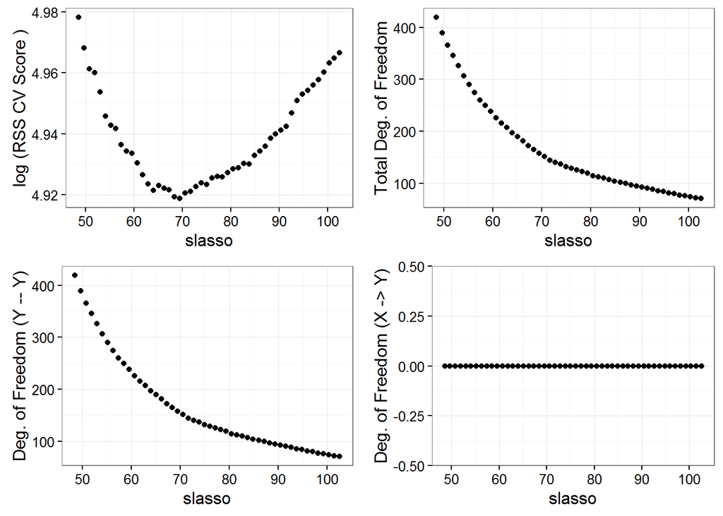

```r
cvVis <- spacemap::tuneVis(cvOut = cvSpaceYY, testSetLen = sapply(testSets, length),
                      tuneParam1 = tsp$slasso, tuneParam1Name = "slasso")
grid.arrange(cvVis[[1]], cvVis[[2]],cvVis[[3]],cvVis[[4]])
```

With a more precise neighborhood of `slasso`, now tuning over `rlasso` and `slasso` will be more manageable.

## Find a neighborhood for `rlasso`

Set up a suitable tuning grid with `slasso` in a neighborhood based on the previous tuning. We expect the `rlasso` parameter to be on approximately the same scale as `slasso`. Just to check, we fit with `rlasso = slasso` to see what the number of `X->Y` edges are returned.

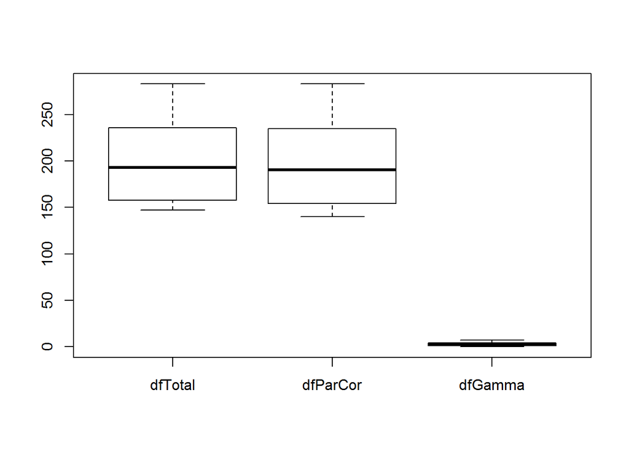

```r
lam1 <- cvSpaceYY$tuneGrid[1]
eps.15 <- 0.15
tg0 <- expand.grid(slasso = seq(lam1*(1 - eps.15), lam1*(1 + eps.15), length = 10),
                    rlasso = lam1,
                    rgroup = 0)
dfr <- spacemap::initFit(dat = dat, method = "spacemap",
                         tuneGrid = tg0,
                         sridge = sridge, tol = tol, cd_iter = cd_iter, iter = iter)
boxplot(dfr[,c("dfTotal", "dfParCor", "dfGamma")])
```

The penalty is too high, with very few `X->Y` edges being considered. Vary `rlasso` downward as a sequence from (85% optimized `slasso`, 15% optimized `slasso`). Vary `slasso` as +/- 15% of the optimized value from previous tunings. Space the grid points on a squared scale. The squared scale grid generates more parsimonious models relative to large models. Essentially, it is computationally wasteful to fit large models until we know these models are better than parsimonious models.

```r
eps.15 <- 0.15
lamg0Lower <- lam1*eps.15
lamg0Upper <- lam1*(1 - eps.15)
tg0 <- expand.grid(slasso = sqrt(seq((lam1*(1 - eps.15))^2, (lam1*(1 + eps.15))^2, length = 5)),
                    rlasso = sqrt(seq(lamg0Upper^2, lamg0Lower^2, length  = 10)),
                    rgroup = 0)
```

Assess whether the tuning grid generates parsimonious models as well as a few large models. The `rlasso` paramter will mostly control the size of `dfGamma` and have limited influence of `dfParCor`.

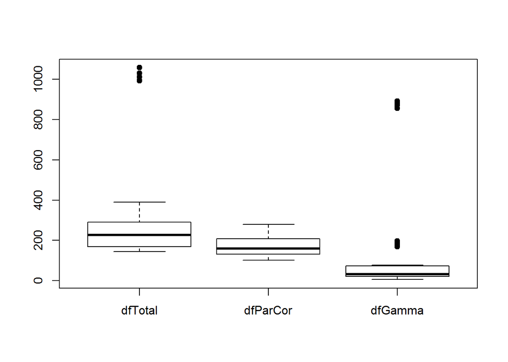

```r
dfr <- spacemap::initFit(dat = dat, method = "spacemap",
                         tuneGrid = tg0,
                         sridge = sridge, tol = tol, cd_iter = cd_iter, iter = iter)
boxplot(dfr[,c("dfTotal", "dfParCor", "dfGamma")], pch = 19)
```

For this example, 1000 edges in the model is too large. If this is known before hand, we can refine the grid to be a little smaller by dropping the 5 outlier models.

```r
tooLarge <- dfr[,"dfTotal"] > 800
summary(tg0[tooLarge,])
```

```
##      slasso          rlasso          rgroup
##  Min.   :59.06   Min.   :10.42   Min.   :0
##  1st Qu.:64.90   1st Qu.:10.42   1st Qu.:0
##  Median :70.26   Median :10.42   Median :0
##  Mean   :69.87   Mean   :10.42   Mean   :0
##  3rd Qu.:75.24   3rd Qu.:10.42   3rd Qu.:0
##  Max.   :79.91   Max.   :10.42   Max.   :0
```

```r
tg0 <- tg0[!tooLarge,]
```

Apply 10-fold cross-validation to select the best tuning parameter set.

```r
tictoc <- system.time({cvG0 <- spacemap::crossValidation(dat = dat, fold = K,
                                                         trainIds = trainSets,  testIds = testSets,
                                                         method = "spacemap", tuneGrid = tg0,
                                                         iter = iter, tol = tol, cd_iter = cd_iter, sridge = sridge,
                                                         refitRidge = refitRidge)})
```

```
## Computing CV scores over the grid...
```

```
## Computing model fit over CV-selected tuning parameters.
```

```r
message("The 10-fold CV took ", round(tictoc[3]/60,2), " minutes")
```

```
## The 10-fold CV took 0.73 minutes
```

Report the CV-selected (`slasso`, `rlasso`). It happens to be in the boundaries. We know have a fairly good intuition about suitable values for `rlasso`.

```r
cvG0$tuneGrid
```

```
##      slasso   rlasso rgroup
## 28 70.26021 40.13267      0
```

Compared to Space with **(X,Y)** input, Spacemap (group = 0) has better power accompanied with a reasonable false discovery rate under the `vote` procedure. The Matthew’s correlation coefficient is higher under the `vote` procedure.

```r
Perf$g0 <- spacemap::cvPerf(cvOut = cvG0, trueParCor = sim1$trueParCor, method = "spacemap")
votePerf(Perf[c("g0", "spaceXY")])
```

|  | power | fdr | mcc | powerXY | fdrXY | powerYY | fdrYY |
| --- | --- | --- | --- | --- | --- | --- | --- |
| g0 | 0.6904762 | 0.0584416 | 0.8043280 | 0.5740741 | 0 | 0.7307692 | 0.0731707 |
| spaceXY | 0.6523810 | 0.0419580 | 0.7885613 | 0.6111111 | 0 | 0.6666667 | 0.0545455 |

Visualize the tuning parameters effect on the degrees of freedom and the CV-error.

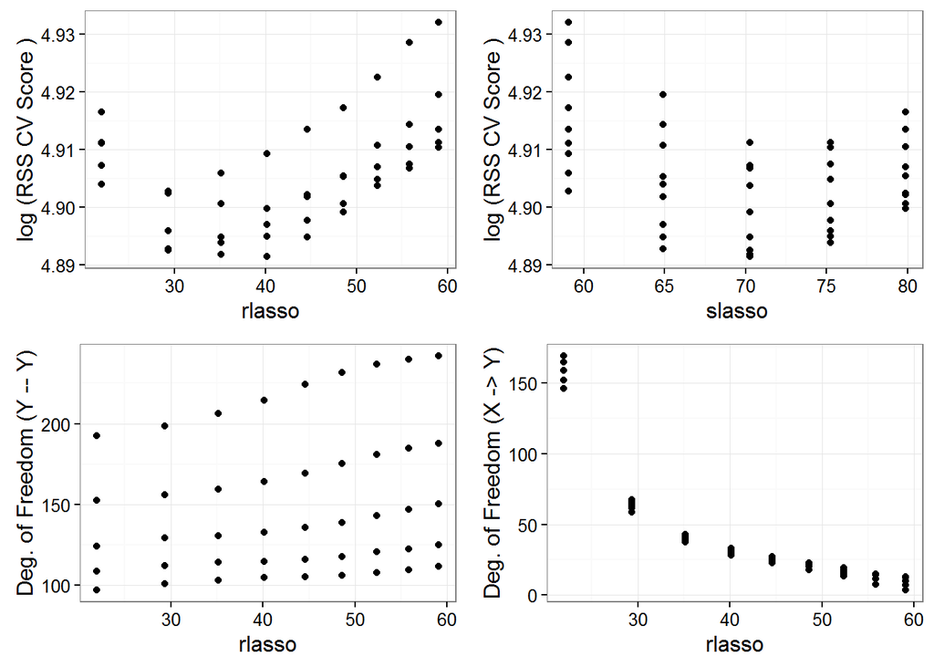

```r
cvVis <- spacemap::tuneVis(cvOut = cvG0, testSetLen = sapply(testSets, length),
                      tuneParam1 = tg0$rlasso, tuneParam1Name = "rlasso")
cvVis2 <- spacemap::tuneVis(cvOut = cvG0, testSetLen = sapply(testSets, length),
                      tuneParam1 = tg0$slasso, tuneParam1Name = "slasso")
library(gridExtra)
grid.arrange(cvVis[[1]], cvVis2[[1]],cvVis[[3]],cvVis[[4]])
```

### Refine `rlasso` choice.

Refine the grid by taking `rlasso` to be in a neighborhood around the previous optimized value from the first tuning.

```r
eps.40 <- .40
lam2 <- cvG0$tuneGrid$rlasso
lamg0Lower <- lam2*(1 -  eps.40)
lamg0Upper <- lam2*(1 + eps.40)
tg02 <- expand.grid(slasso = unique(sort(tg0$slasso)),
                    rlasso = sqrt(seq(lamg0Upper^2, lamg0Lower^2, length  = 10)),
                    rgroup = 0)
```

Reapply 10-fold cross-validation to explore the `rlasso` space more densely.

```r
tictoc <- system.time({cvG02 <- spacemap::crossValidation(dat = dat, fold = K,
                                                         trainIds = trainSets,  testIds = testSets,
                                                         method = "spacemap", tuneGrid = tg02,
                                                         iter = iter, tol = tol, cd_iter = cd_iter, sridge = sridge,
                                                         refitRidge = refitRidge)})
```

```
## Computing CV scores over the grid...
```

```
## Computing model fit over CV-selected tuning parameters.
```

```r
message("The 10-fold CV took ", round(tictoc[3]/60,2), " minutes")
```

```
## The 10-fold CV took 0.8 minutes
```

The refined `rlasso` selection is very near the previous tuning grid.

```r
#previous selection
cvG0$tuneGrid
```

```
##      slasso   rlasso rgroup
## 28 70.26021 40.13267      0
```

```r
#refined selection
cvG02$tuneGrid
```

```
##      slasso   rlasso rgroup
## 38 70.26021 33.94843      0
```

```r
lam2.2 <- cvG02$tuneGrid$rlasso
```

Refining the `rlasso` uniformly improves the power and the Mathew’s correlation coefficient.

|  | power | fdr | mcc | powerXY | fdrXY | powerYY | fdrYY |
| --- | --- | --- | --- | --- | --- | --- | --- |
| g02 | 0.7285714 | 0.0727273 | 0.8200269 | 0.7222222 | 0.0714286 | 0.7307692 | 0.0731707 |
| g0 | 0.6904762 | 0.0584416 | 0.8043280 | 0.5740741 | 0.0000000 | 0.7307692 | 0.0731707 |

Again, we see a clear minimizer in the CV-error curve when you profile each minimizer.

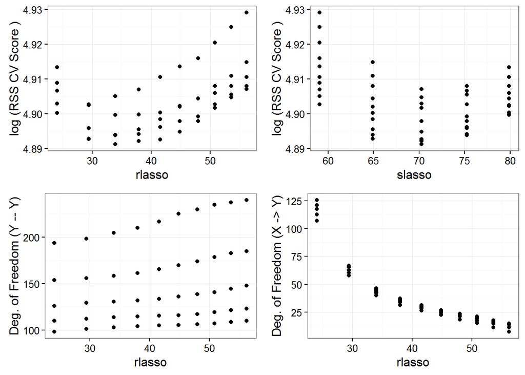

```r
cvVis <- spacemap::tuneVis(cvOut = cvG02, testSetLen = sapply(testSets, length),
                      tuneParam1 = tg02$rlasso, tuneParam1Name = "rlasso")
cvVis2 <- spacemap::tuneVis(cvOut = cvG02, testSetLen = sapply(testSets, length),
                      tuneParam1 = tg02$slasso, tuneParam1Name = "slasso")
library(gridExtra)
grid.arrange(cvVis[[1]], cvVis2[[1]],cvVis[[3]],cvVis[[4]])
```

## Find a neighborhood for `rgroup`

Construct a tuning grid using the previous tunings information. Use the same `slasso` tuning grid from the tuning of Spacemap (Group = 0). If there is a non-zero group penalty, the CV-error selected `rlasso` penalty is generally smaller from the (Group = 0) tuning. We set the `rlasso` penalty grid to be between 50% and 110% of the selected value anticipating some decrease in global `X->Y` penalty. Both `slasso` and `rlasso` are placed on the squared scale. The `rgroup` penalty is bounded between zero and the `rlasso` selected from (Group = 0) tuning. The `rgroup` penalty is on the log scale for several reasons; (i) we already have a well-tuned `slasso` and `rlasso` penalties maintaing global sparisty; (ii) this final tuning is more subtle and is looking to find any master predictors that influence multiple responses. The size of the tuning grid depends on computational resources available. We recommend starting small and iteratively narrowing down the neighborhood.

```r
eps.50 <- 0.5
eps.10 <- 0.1
tmap <- expand.grid(slasso = sort(unique(tg02$slasso)),
                    rlasso = sqrt(seq((lam2.2*(1 - eps.50))^2, (lam2.2*(1 + eps.10))^2, length = 5)),
                    rgroup = exp(seq(log(1.5), log(lam2.2), length = 5)))
```

Apply 10-fold cross-validation to select the best tuning parameter set.

```r
tictoc <- system.time({cvSpmap <- spacemap::crossValidation(dat = dat, fold = K,
                                                            trainIds = trainSets,  testIds = testSets,
                                                            method = "spacemap", tuneGrid = tmap,
                                                            iter = iter, tol = tol, cd_iter = cd_iter, sridge = sridge,
                                                            refitRidge = refitRidge)})
```

```
## Computing CV scores over the grid...
```

```
## Computing model fit over CV-selected tuning parameters.
```

```r
message("The 10-fold CV took ", round(tictoc[3]/60,2), " minutes")
```

```
## The 10-fold CV took 1.97 minutes
```

The tuning parameter selection is bounded within the range of the tuning grid.

```r
cvSpmap$tuneGrid
```

```
##      slasso   rlasso   rgroup
## 88 70.26021 29.00555 15.56459
```

The performance of Spacemap improves over Group = 0 in the power of the `X->Y` edges. Since the X’s in this simulation are hub variables, the MAP penalty is superior.

```r
Perf$spmap <- spacemap::cvPerf(cvOut = cvSpmap, trueParCor = sim1$trueParCor, method = "spacemap")
votePerf(Perf[c("spmap", "g02")])
```

|  | power | fdr | mcc | powerXY | fdrXY | powerYY | fdrYY |
| --- | --- | --- | --- | --- | --- | --- | --- |
| spmap | 0.7571429 | 0.0701754 | 0.8372817 | 0.8518519 | 0.0612245 | 0.7243590 | 0.0737705 |
| g02 | 0.7285714 | 0.0727273 | 0.8200269 | 0.7222222 | 0.0714286 | 0.7307692 | 0.0731707 |

Visualize the tuning parameters effect on the degrees of freedom and the loss function.

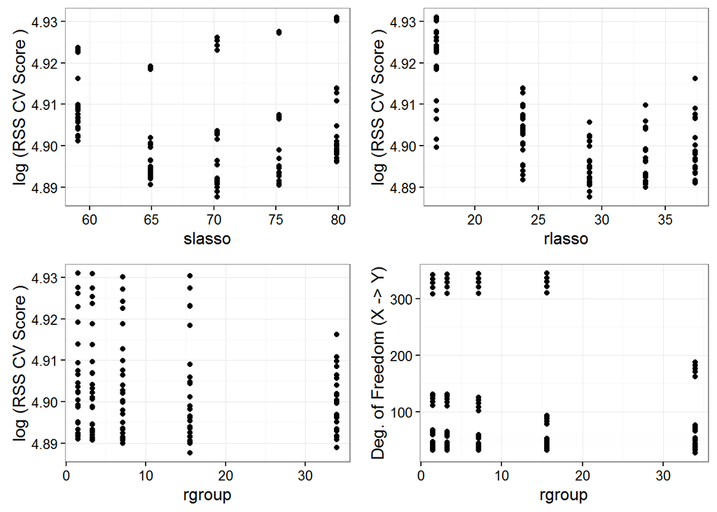

```r
cvVis1 <- spacemap::tuneVis(cvOut = cvSpmap, testSetLen = sapply(testSets, length),
                      tuneParam1 = tmap$slasso, tuneParam1Name = "slasso")
cvVis2 <- spacemap::tuneVis(cvOut = cvSpmap, testSetLen = sapply(testSets, length),
                      tuneParam1 = tmap$rlasso, tuneParam1Name = "rlasso")
cvVis3 <- spacemap::tuneVis(cvOut = cvSpmap, testSetLen = sapply(testSets, length),
                      tuneParam1 = tmap$rgroup, tuneParam1Name = "rgroup")
library(gridExtra)
grid.arrange(cvVis1[[1]], cvVis2[[1]],cvVis3[[1]],cvVis3[[4]])
```

## Refine Spacemap Grid

Well-designed tuning grids inform future tuning refinements. We narrow the range of each tuning parameter to be within some neighborhood of the current optimized value: +/- 7.5% of `slasso`; +/- 15% of `rlasso`; and +/- 40% of `rgroup`. The range of the parameters is inversely related to the level of confidence we have in the current optimized value.

```r
eps.075 <- 0.075
lam2.3 <- cvSpmap$tuneGrid$rlasso
lam3 <- cvSpmap$tuneGrid$rgroup
tmap2 <- expand.grid(slasso = sqrt(seq((lam1*(1 - eps.075))^2, (lam1*(1 + eps.075))^2, length = 5)),
                     rlasso = sqrt(seq((lam2.3*(1 - eps.15))^2, (lam2.3*(1 + eps.15))^2, length = 10)),
                     rgroup = exp(seq(log(lam3*(1 - eps.40)), log(lam3*(1 + eps.40)), length = 10)))
```

```r
tictoc <- system.time({cvSpmap2 <- spacemap::crossValidation(dat = dat, fold = K,
                                                            trainIds = trainSets,  testIds = testSets,
                                                            method = "spacemap", tuneGrid = tmap2,
                                                            iter = iter, tol = tol, cd_iter = cd_iter, sridge = sridge,
                                                            refitRidge = refitRidge)})
```

```
## Computing CV scores over the grid...
```

```
## Computing model fit over CV-selected tuning parameters.
```

```r
message("The 10-fold CV took ", round(tictoc[3]/60,2), " minutes")
```

```
## The 10-fold CV took 7.45 minutes
```

The tuning grid selection is:

```r
cvSpmap2$tuneGrid
```

```
##       slasso   rlasso   rgroup
## 173 69.67802 28.84801 12.38648
```

The refined grid improves the Spacemap performance in power and fdr of the `Y--Y` edges.

```r
Perf$spmap2 <- spacemap::cvPerf(cvOut = cvSpmap2, trueParCor = sim1$trueParCor, method = "spacemap")
votePerf(Perf[c("spmap2", "spmap")])
```

|  | power | fdr | mcc | powerXY | fdrXY | powerYY | fdrYY |
| --- | --- | --- | --- | --- | --- | --- | --- |
| spmap2 | 0.7666667 | 0.0693642 | 0.8429589 | 0.8518519 | 0.0612245 | 0.7371795 | 0.0725806 |
| spmap | 0.7571429 | 0.0701754 | 0.8372817 | 0.8518519 | 0.0612245 | 0.7243590 | 0.0737705 |

Visualize the tuning parameters effect on the degrees of freedom and the loss function.

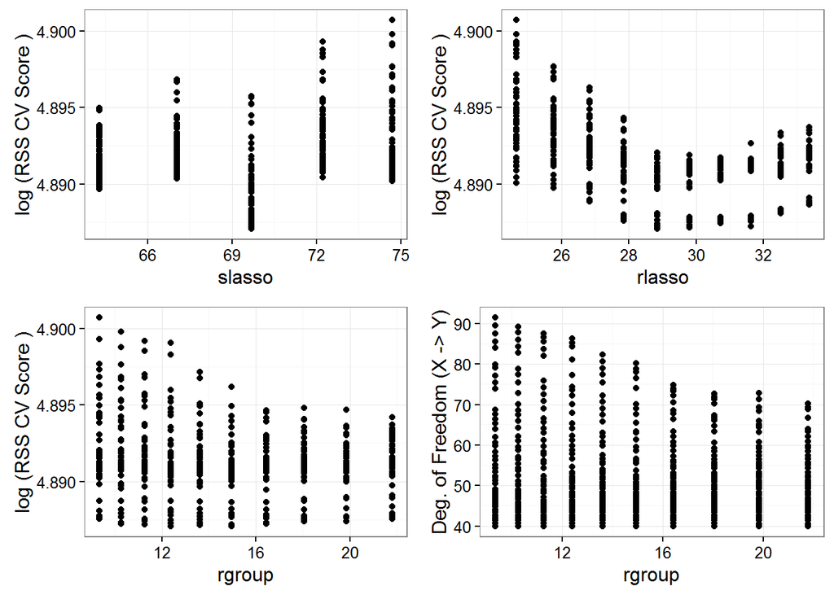

```r
cvVis1 <- spacemap::tuneVis(cvOut = cvSpmap2, testSetLen = sapply(testSets, length),
                      tuneParam1 = tmap2$slasso, tuneParam1Name = "slasso")
cvVis2 <- spacemap::tuneVis(cvOut = cvSpmap2, testSetLen = sapply(testSets, length),
                      tuneParam1 = tmap2$rlasso, tuneParam1Name = "rlasso")
cvVis3 <- spacemap::tuneVis(cvOut = cvSpmap2, testSetLen = sapply(testSets, length),
                      tuneParam1 = tmap2$rgroup, tuneParam1Name = "rgroup")
library(gridExtra)
grid.arrange(cvVis1[[1]], cvVis2[[1]],cvVis3[[1]],cvVis3[[4]])
```

Save the results.

```r
save.image("~/scratch-data/spacemap/sim1_tutorial.RData")
```

## Evaluating the tuning cost and benefits.

Disciplined tuning of Spacemap parameters yields real improvements in power at comparablely low FDR thresholds for this hub network simulation, where some hubs are predictor variables. We have provided a reasonable tuning framework that balances the trade-off of model accuracy and computational speed. Testing the robustness of this tuning framework needs to be explored with respect to changes in sample size, network topology, and other factors like signal to noise ratio and distributional assumptions.

```r
votePerf(Perf[c("spmap2", "g02", "spaceXY")])
```

|  | power | fdr | mcc | powerXY | fdrXY | powerYY | fdrYY |
| --- | --- | --- | --- | --- | --- | --- | --- |
| spmap2 | 0.7666667 | 0.0693642 | 0.8429589 | 0.8518519 | 0.0612245 | 0.7371795 | 0.0725806 |
| g02 | 0.7285714 | 0.0727273 | 0.8200269 | 0.7222222 | 0.0714286 | 0.7307692 | 0.0731707 |
| spaceXY | 0.6523810 | 0.0419580 | 0.7885613 | 0.6111111 | 0.0000000 | 0.6666667 | 0.0545455 |

Terminate the parallel backend.

```r
stopCluster(cl)
```